# Лабораторная работа №4. Работа с программными пакетами

## Документация lynx

```bash
rpm -qd lynx
man lynx
```

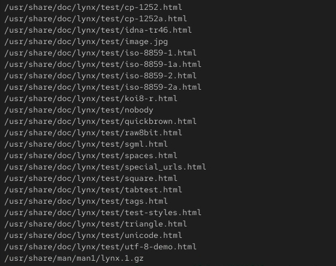

Рисунок 30: Список документации (вывод)

## Конфигурационные файлы и скрипты lynx

- Вывел на экран перечень и месторасположение конфигурационных файлов пакета (рис. 32)

```bash
rpm -qc lynx
```

- Вывел на экран расположение и содержание скриптов, выполняемых при установке пакета (рис. 33)

```bash
rpm -q --scripts lynx
```

- Вывод пуст, что означает отсутствие скриптов установки/удаления для пакета `lynx`

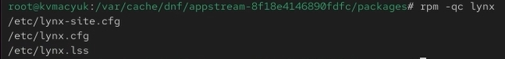

Рисунок 32: Поиск конфигурационных файлов

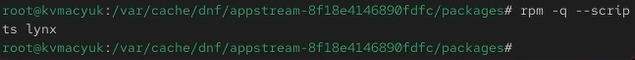

Рисунок 33: Проверка скриптов установки

## Проверка и удаление lynx

- В отдельном терминале под своей учётной записью запустил текстовый браузер `lynx`, чтобы проверить корректность установки пакета (рис. 34, рис. 35)
- Вернулся в терминал с учётной записью root и удалил пакет (рис. 36)

```bash
rpm -e lynx
ls
```

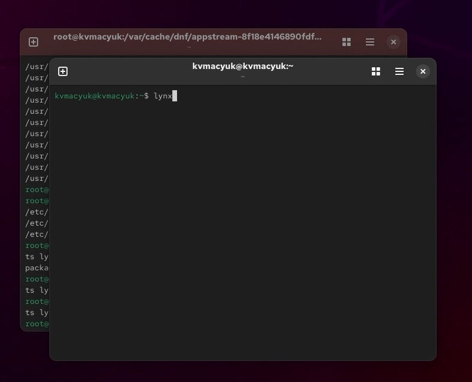

Рисунок 34: Запуск lynx из-под обычного пользователя

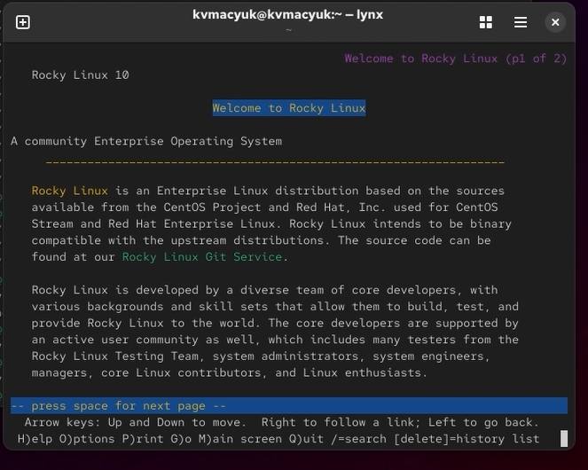

Рисунок 35: Работа в текстовом браузере

## Удаление пакета через rpm

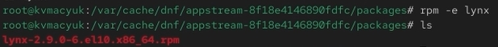

Рисунок 36: Удаление пакета через rpm

## Установка dnsmasq

- Предположим, что требуется из rpm-пакетов установить `dnsmasq` (DNS-, DHCP- и TFTP-сервер)
- Установил пакет `dnsmasq` и определил расположение исполняемого файла (рис. 37—рис. 39)

```bash
dnf list dnsmasq
dnf install dnsmasq
which dnsmasq
```

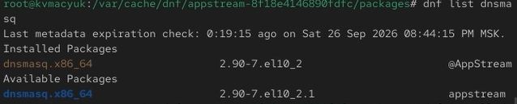

Рисунок 37: Сравнение версий dnsmasq

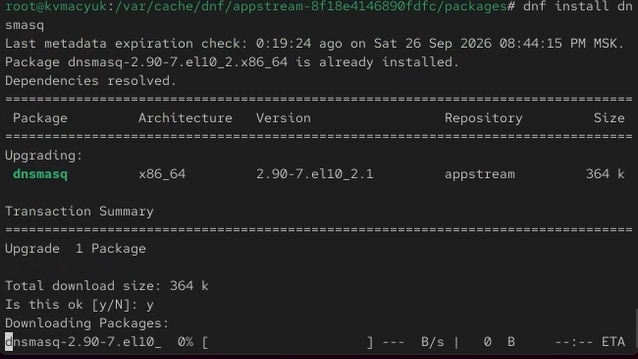

Рисунок 38: Обновление пакета dnsmasq

## Определение пути dnsmasq

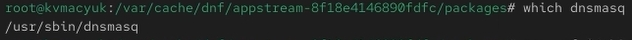

Рисунок 39: Определение пути dnsmasq

## Информация о dnsmasq

- Определил по имени файла, к какому пакету принадлежит `dnsmasq`, и получил дополнительную информацию о содержимом пакета (рис. 40—рис. 43)

```bash
rpm -qf $(which dnsmasq)
rpm -qi dnsmasq
```

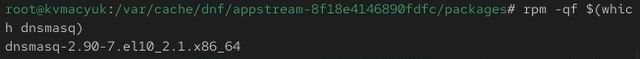

Рисунок 40: Проверка владельца файла

[figure not shown]

Рисунок 41: Список файлов пакета dnsmasq

## Запрос детальной информации

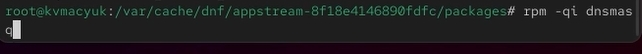

Рисунок 42: Запрос детальной информации

## Детальная информация о dnsmasq

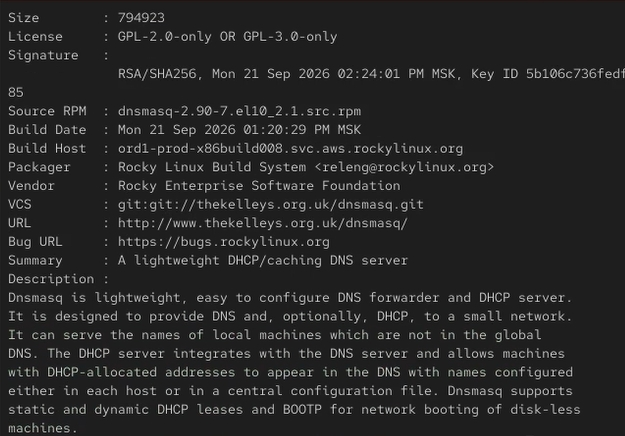

Рисунок 43: Детальная информация о dnsmasq

## Документация и конфигурация dnsmasq

- Получил список всех файлов в пакете, а также вывел перечень файлов с документацией пакета (рис. 44—рис. 46). Посмотрел файлы документации, применив команду `man dnsmasq`

```bash
rpm -ql dnsmasq
rpm -qd dnsmasq
man dnsmasq
```

- Вывел на экран перечень и месторасположение конфигурационных файлов пакета (рис. 48)

```bash
rpm -qc dnsmasq
```

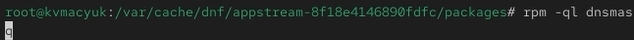

Рисунок 44: Запрос списка файлов

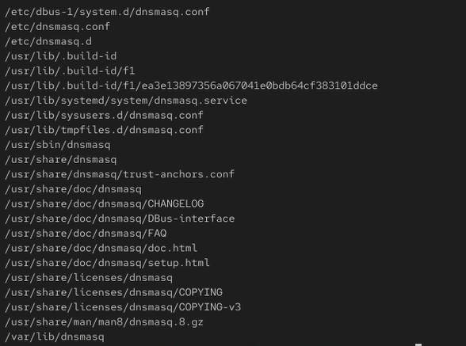

Рисунок 45: Список файлов (повтор)

## Список документации dnsmasq

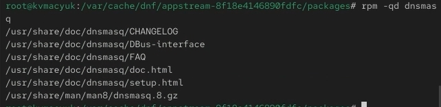

Рисунок 46: Список документации dnsmasq

## Скрипты и удаление dnsmasq

```bash
rpm -q --scripts dnsmasq
```

```bash
rpm -e dnsmasq
ls
```

[output not shown]

[figure not shown]

[figure not shown]

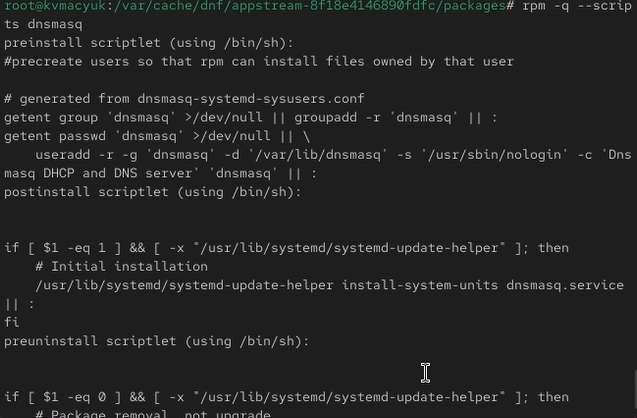

# Ответы на контрольные вопросы

## Вопросы 1–3

**1. Какая команда позволяет вам искать пакет rpm, содержащий файл useradd?**

Для поиска пакета, содержащего файл `useradd`, используется команда `dnf provides */useradd` или `dnf provides "*bin/useradd"`. Также можно использовать `rpm -qf $(which useradd)`, если файл уже установлен в системе.

**2. Какие команды вам нужно использовать, чтобы показать имя группы dnf, которая содержит инструменты безопасности и показывает, что находится в этой группе?**

Для отображения списка групп пакетов используется команда `dnf grouplist`. Для получения информации о конкретной группе, содержащей инструменты безопасности (например, «Security Tools»), используется команда `dnf groupinfo "Security Tools"`.

**3. Какая команда позволяет вам установить rpm, который вы загрузили из Интернета и который не находится в репозиториях?**

Для установки локального rpm-пакета используется команда `rpm -Uhv имя_пакета.rpm` или `dnf install имя_пакета.rpm`. Также можно использовать `dnf install http://server/repo/имя_пакета.rpm` для установки из сети.

## Вопросы 4–6

**4. Вы хотите убедиться, что пакет rpm, который вы загрузили, не содержит никакого опасного кода сценария. Какая команда позволяет это сделать?**

Для просмотра скриптов, выполняемых при установке/удалении пакета, используется команда `rpm -q --scripts имя_пакета`. Она выводит содержимое скриптов, что позволяет проверить их на наличие опасных действий.

**5. Какая команда показывает всю документацию в rpm?**

Для отображения списка файлов документации, входящих в пакет, используется команда `rpm -qd имя_пакета`. Для просмотра всей документации можно также использовать `rpm -ql имя_пакета | grep -E 'man|doc|html'`.

**6. Какая команда показывает, какому пакету rpm принадлежит файл?**

Для определения принадлежности файла к пакету используется команда `rpm -qf путь_к_файлу`. Например, `rpm -qf $(which lynx)`.

# Результаты и выводы

## Полученные навыки

- Получены навыки работы с репозиториями и менеджерами пакетов
- Изучены основные команды `dnf` для поиска, установки, обновления, удаления пакетов и работы с историей действий
- Освоены команды `rpm` для получения информации о пакетах, их файлах, документации, конфигурационных файлах и скриптах установки
- Изучено расположение конфигурационных файлов `dnf` и репозиториев

# Список литературы